# Project1

Peter Gray, Ashley King, James Kolesar

3/25/2020

There are many factors that come into play when looking for a house, and it’s important to know how the different attributes of a house affect its price when weighing your priorities with your budget. We’re examining a set of housing data from Oregon to help determine which factors most simply and most accurately predict the cost of a home.

# 1) Data Summary

First let’s take a look at a summary for all of the different vairables provided in the study:

```r
summary(housing)
```

```
##        id            price            size            lot
##  Min.   : 1.00   Min.   :155.5   Min.   :1.440   Min.   : 1.000
##  1st Qu.:19.75   1st Qu.:242.8   1st Qu.:1.861   1st Qu.: 3.000
##  Median :38.50   Median :276.0   Median :1.966   Median : 4.000
##  Mean   :38.50   Mean   :285.8   Mean   :1.970   Mean   : 3.987
##  3rd Qu.:57.25   3rd Qu.:336.8   3rd Qu.:2.107   3rd Qu.: 5.000
##  Max.   :76.00   Max.   :450.0   Max.   :2.896   Max.   :11.000
##       bath          bedrooms       yearbuilt    agestandardized
##  Min.   :1.000   Min.   :2.000   Min.   :1905   Min.   :-6.50000
##  1st Qu.:2.000   1st Qu.:3.000   1st Qu.:1958   1st Qu.:-1.22500
##  Median :2.000   Median :3.000   Median :1970   Median :-0.05000
##  Mean   :2.208   Mean   :3.447   Mean   :1969   Mean   :-0.05921
##  3rd Qu.:3.000   3rd Qu.:4.000   3rd Qu.:1980   3rd Qu.: 1.00000
##  Max.   :3.100   Max.   :6.000   Max.   :2005   Max.   : 3.50000
##    garagesize       status              elem
##  Min.   :0.000   Length:76          Length:76
##  1st Qu.:1.000   Class :character   Class :character
##  Median :2.000   Mode  :character   Mode  :character
##  Mean   :1.566
##  3rd Qu.:2.000
##  Max.   :3.000
```

## A few things to note for each of our variables:

- ID:
  - Each home was assigned a number to help distinguish each data entry. In this study, this variable will be used to refer to individual homes but has no bearing in predicting the cost of a home.
- Price:
  - The cost of a home, in thousands of dollars. This will act as our response variable.
- Size:
  - The size of a home, in thousands of square feet.
- Lot:
  - A whole number ranging from 1 to 11 measuring the size of the lot that comes with the home, 1 being the smallest.
- Bath:
  - The number of bathrooms.
- Bedrooms:
  - The number of bedrooms.
- YearBuilt:
  - The year the house was built. Goes hand in hand with the following variable.
- AgeStandardized:
  - Takes the year that the house was built and puts it into the following calculation: (YearBuilt - 1970)/10. This keeps our data points more in line with our other variables, ranging from -6.5 to 3.5, rather than 1905 to 2005
- GarageSize:
  - A measure of the size of each home’s garage based on how many cars can fit in it.
- Status
  - A categorical variable specifying whether the house was already sold, a pending sale, or an active listing.
- Elem:
  - A categorical variable specifying the elementary school district for each house.

## A few things to note in general moving forward:

- First impressions:
  - Any of these variables intuitively play a role in determining the price of a house, but some may be much more influential than others. A few of these variables might also prove others obsolete: things like the size of a house, the size of the lot, and the number of bathrooms/bedrooms are all most likely very closely tied together, so all four might not be necessary for a model. Apart from obsoleteness, something like location is a complex variable to examine, and simply knowing which elementary school district a house falls into does not paint the whole picture. We should definitely be careful with intuitively obvious assumptions.
- Outliers:
  - A few of our variables have notable outliers that we might need to be cautious of. A lot size of 11 and a 6 bedroom house suggest there might be some mansion level homes on the market, which contrast the typical home in our data. There is also a very old house, built at the beginning of the 1900s.

## Checking for missing values

```r
sum(is.na(housing))
```

```
## [1] 0
```

- There are 0 variables that have missing data in our dataset.

# 2) Exploratory Data Analysis

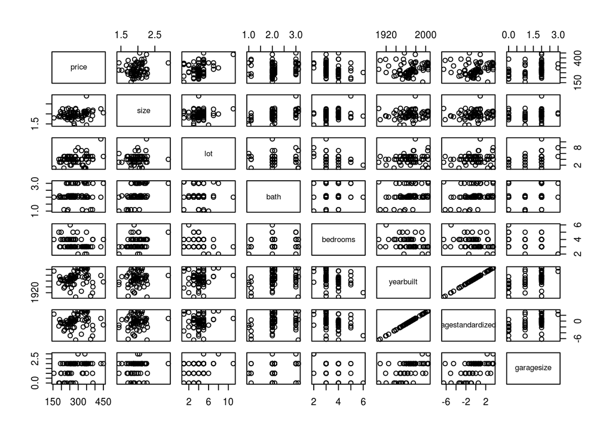

```r
housing_numeric <- housing[2:9]
pairs(housing_numeric)
```

```r
cor(log(housing$price), housing_numeric)
```

```
##          price      size       lot      bath   bedrooms yearbuilt
## [1,] 0.9909838 0.1877631 0.2341121 0.1862792 -0.3035113  0.165688
##      agestandardized garagesize
## [1,]        0.165688  0.3862127
```

- Since price is so large, for the rest of the EDA, we will be using a log of price
  - This will reduce the SE.
- It appears that garazesize, bedroom, lot, bath, and size have a weak correlation to price
- Bath, yearbuilt, and agestandardized have a weaker correlation
  - (Yearbuilt and agestandardized will not be used together in the same model)

```r
housing$logprice <- log(housing$price)
```

## 2.1)Bath

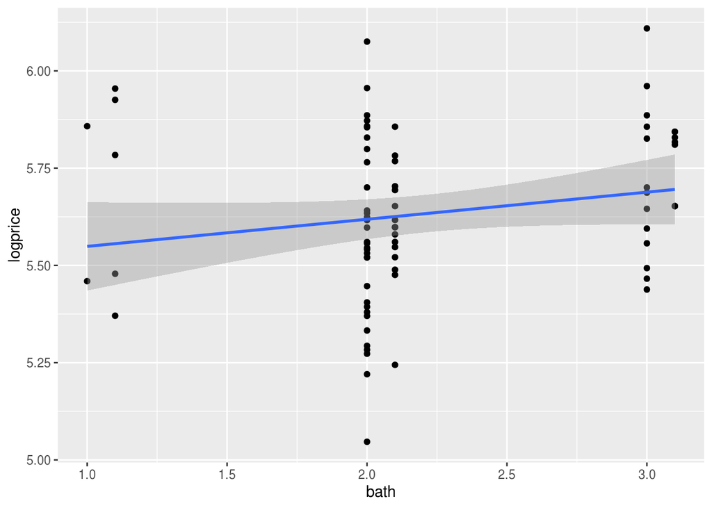

```r
ggplot(housing, aes(x = bath, y = logprice)) +
  geom_point() +
  geom_smooth(method = "lm")
```

- The data seems spread out in chunks, maybe performing a squared or cubic function to bath would help

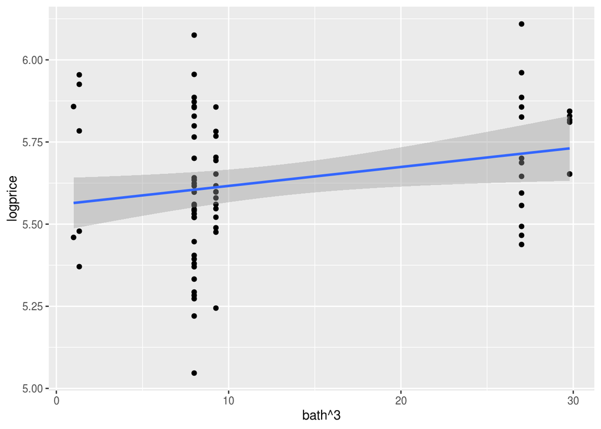

```r
ggplot(housing, aes(x = bath^3, y = logprice)) +
  geom_point() +
  geom_smooth(method = "lm")
```

- There is now a reasonable straight line, with a well spread SE, that could be used in a model.

```r
housing$bathcubed <- housing$bath ^ 3
summary(lm(logprice ~ bathcubed, data = housing))
```

```
##
## Call:
## lm(formula = logprice ~ bathcubed, data = housing)
##
## Residuals:
##      Min       1Q   Median       3Q      Max
## -0.55819 -0.12061 -0.01404  0.14551  0.47051
##
## Coefficients:
##             Estimate Std. Error t value Pr(>|t|)
## (Intercept)  5.55867    0.04083 136.143   <2e-16 ***
## bathcubed    0.00577    0.00257   2.245   0.0277 *
## ---
## Signif. codes:  0 '***' 0.001 '**' 0.01 '*' 0.05 '.' 0.1 ' ' 1
##
## Residual standard error: 0.2078 on 74 degrees of freedom
## Multiple R-squared:  0.06378,    Adjusted R-squared:  0.05113
## F-statistic: 5.041 on 1 and 74 DF,  p-value: 0.02774
```

- Bath is now statistically significant

## 2.2)Size

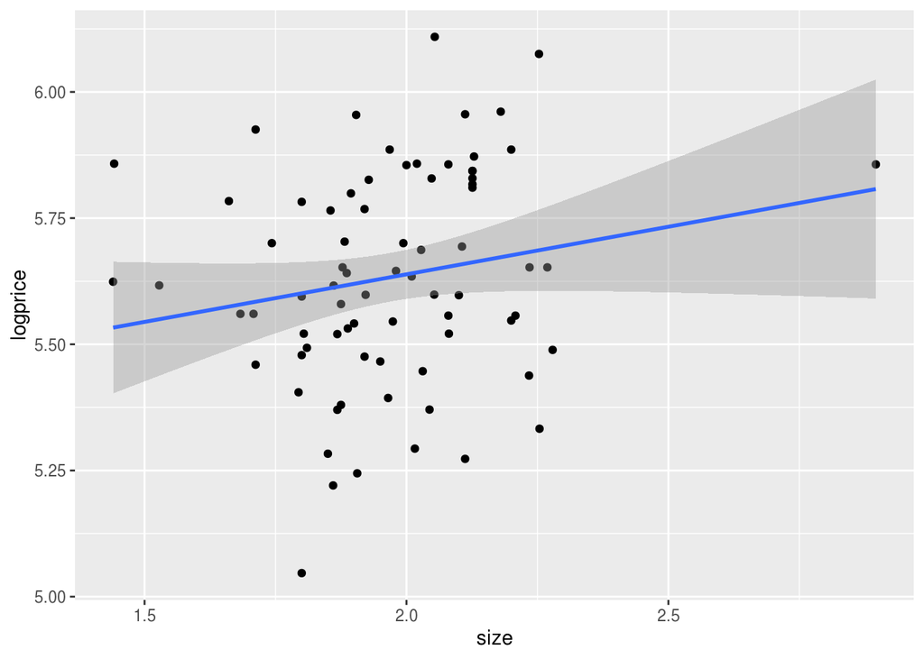

```r
ggplot(housing, aes(x = size, y = logprice)) +
  geom_point() +
  geom_smooth(method = "lm", se=TRUE)
```

- There is a reasonable straight line, but the SE around the edges is high.
- There appears to be one outlier, we will try and reduce the impact of it using a function on size

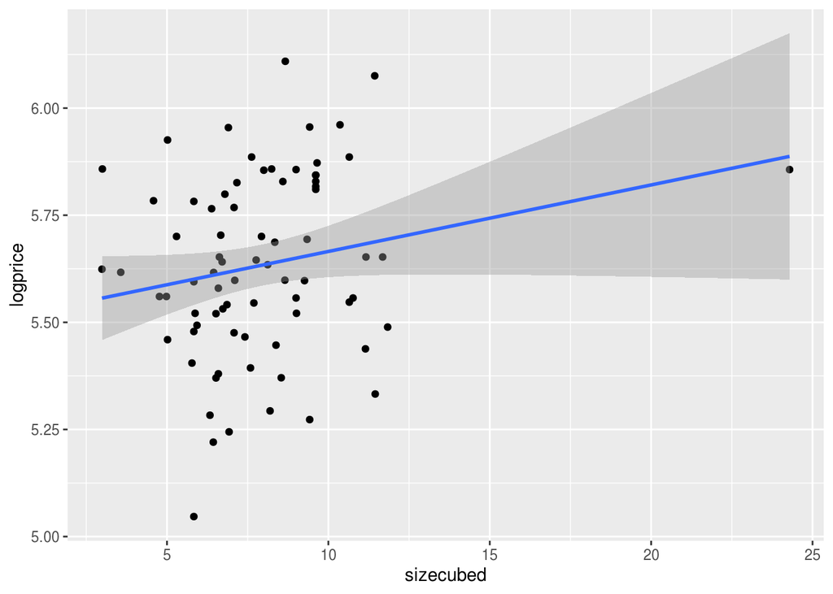

```r
sizecubed <- (housing$size) ^ (3)
ggplot(housing, aes(x = sizecubed, y = logprice)) +
  geom_point() +
  geom_smooth(method = "lm", se=TRUE)
```

- We now have less errors in the small values of size, but the SE is worse for large sizes

```r
summary(lm(logprice ~ sizecubed, data = housing))
```

```
##
## Call:
## lm(formula = logprice ~ sizecubed, data = housing)
##
## Residuals:
##      Min       1Q   Median       3Q      Max
## -0.55404 -0.12838 -0.01415  0.18207  0.46455
##
## Coefficients:
##             Estimate Std. Error t value Pr(>|t|)
## (Intercept) 5.510111   0.072928  75.556   <2e-16 ***
## sizecubed   0.015531   0.008691   1.787    0.078 .
## ---
## Signif. codes:  0 '***' 0.001 '**' 0.01 '*' 0.05 '.' 0.1 ' ' 1
##
## Residual standard error: 0.2103 on 74 degrees of freedom
## Multiple R-squared:  0.04137,    Adjusted R-squared:  0.02842
## F-statistic: 3.194 on 1 and 74 DF,  p-value: 0.07802
```

- Even after performing a transformation, size is still not significant.

## 2.3)Lot

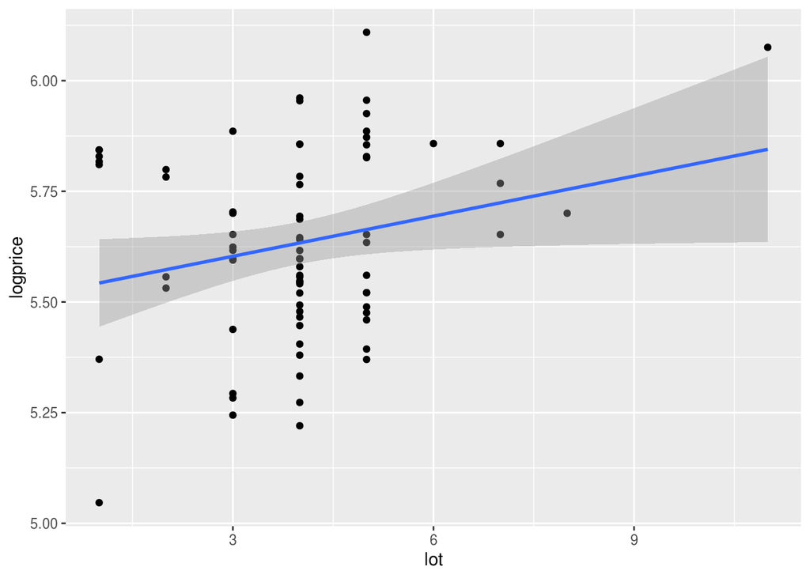

```r
ggplot(housing, aes(x = lot, y = logprice)) +
  geom_point() +
  geom_smooth(method = "lm")
```

- We still have a high SE around the large value of lot, but it fits the data well.

```r
summary(lm(logprice ~ lot, data = housing))
```

```
##
## Call:
## lm(formula = logprice ~ lot, data = housing)
##
## Residuals:
##      Min       1Q   Median       3Q      Max
## -0.49623 -0.14572 -0.01374  0.17155  0.44554
##
## Coefficients:
##             Estimate Std. Error t value Pr(>|t|)
## (Intercept)  5.51267    0.06288  87.670   <2e-16 ***
## lot          0.03021    0.01458   2.071   0.0418 *
## ---
## Signif. codes:  0 '***' 0.001 '**' 0.01 '*' 0.05 '.' 0.1 ' ' 1
##
## Residual standard error: 0.2088 on 74 degrees of freedom
## Multiple R-squared:  0.05481,    Adjusted R-squared:  0.04204
## F-statistic: 4.291 on 1 and 74 DF,  p-value: 0.0418
```

- There appears to be a positive correlation between lot and the log of price, and no transformation needed

## 2.4)Garagesize

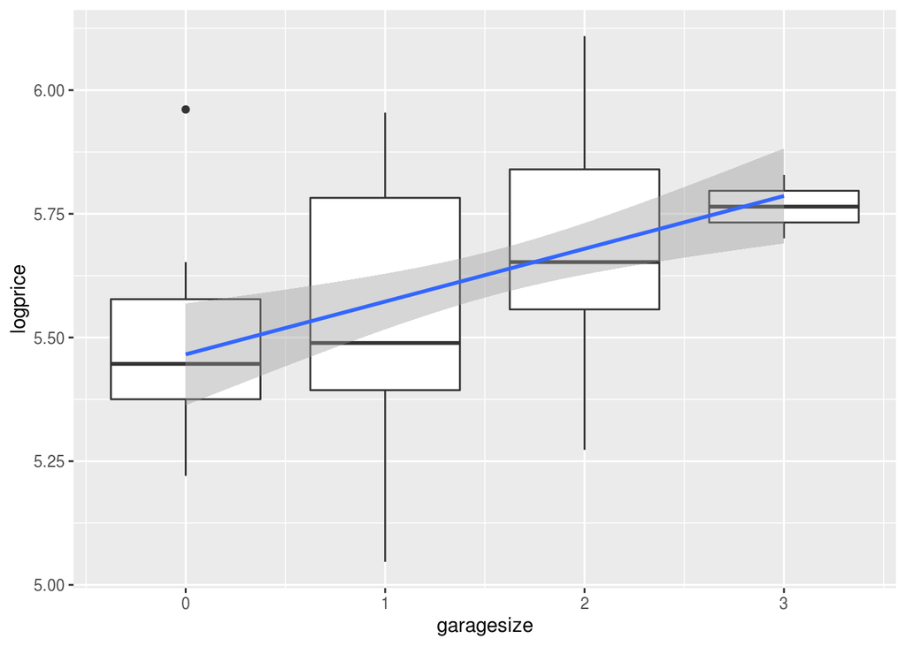

```r
ggplot(housing, aes(x = garagesize, y = logprice, group = garagesize)) +
  geom_boxplot() +
  geom_smooth(method = "lm", se=TRUE, aes(group=1))
```

- There appears to be a positive correlation between garagesize and price
- As the garagesize increases, so does the price, on average

```r
summary(lm(logprice ~ garagesize, data = housing))
```

```
##
## Call:
## lm(formula = logprice ~ garagesize, data = housing)
##
## Residuals:
##      Min       1Q   Median       3Q      Max
## -0.52606 -0.12263 -0.03049  0.15314  0.49505
##
## Coefficients:
##             Estimate Std. Error t value Pr(>|t|)
## (Intercept)  5.46595    0.05167 105.781  < 2e-16 ***
## garagesize   0.10675    0.02964   3.602 0.000569 ***
## ---
## Signif. codes:  0 '***' 0.001 '**' 0.01 '*' 0.05 '.' 0.1 ' ' 1
##
## Residual standard error: 0.1981 on 74 degrees of freedom
## Multiple R-squared:  0.1492, Adjusted R-squared:  0.1377
## F-statistic: 12.97 on 1 and 74 DF,  p-value: 0.0005693
```

- Garagesize is very significant, and no transformation is needed.

## 2.5) Elem

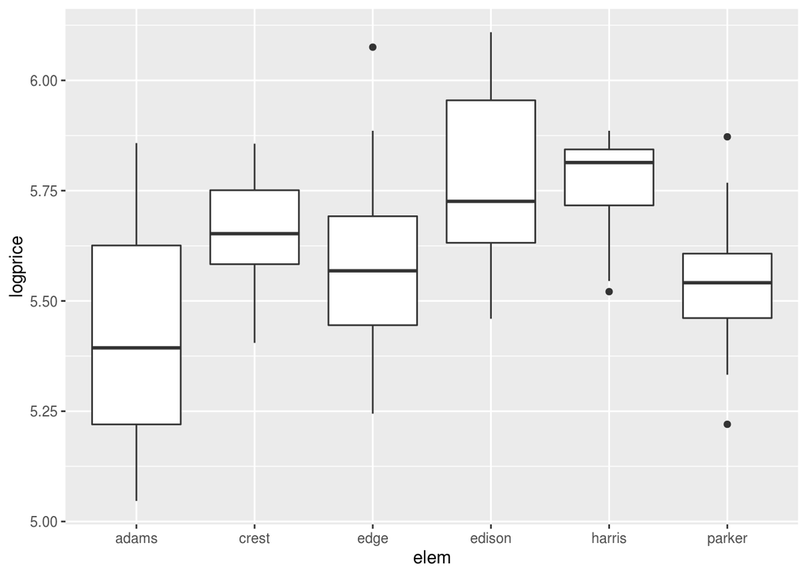

```r
ggplot(housing, aes(x = elem, y = logprice, group = elem)) +
  geom_boxplot()
```

```r
summary(lm(logprice ~ elem, data = housing))
```

```
##
## Call:
## lm(formula = logprice ~ elem, data = housing)
##
## Residuals:
##      Min       1Q   Median       3Q      Max
## -0.38609 -0.13120  0.00523  0.11265  0.49933
##
## Coefficients:
##             Estimate Std. Error t value Pr(>|t|)
## (Intercept)   5.4327     0.1117  48.622  < 2e-16 ***
## elemcrest     0.2190     0.1368   1.600  0.11399
## elemedge      0.1433     0.1180   1.214  0.22874
## elemedison    0.3380     0.1249   2.705  0.00856 **
## elemharris    0.3257     0.1231   2.645  0.01007 *
## elemparker    0.1049     0.1224   0.857  0.39451
## ---
## Signif. codes:  0 '***' 0.001 '**' 0.01 '*' 0.05 '.' 0.1 ' ' 1
##
## Residual standard error: 0.1935 on 70 degrees of freedom
## Multiple R-squared:  0.2318, Adjusted R-squared:  0.177
## F-statistic: 4.225 on 5 and 70 DF,  p-value: 0.002053
```

## 3) Initial Modeling

Having now taken all of the best information from the explorations above, we now build a model using the most significant variables from above.

```r
ModelonPrice <- lm(housing$price ~ housing$bathcubed + housing$lot + housing$garagesize)
summary(ModelonPrice)
```

```
##
## Call:
## lm(formula = housing$price ~ housing$bathcubed + housing$lot +
##     housing$garagesize)
##
## Residuals:
##    Min     1Q Median     3Q    Max
## -92.16 -34.11 -11.07  38.30 129.24
##
## Coefficients:
##                    Estimate Std. Error t value Pr(>|t|)
## (Intercept)        200.1685    21.5199   9.302 5.75e-14 ***
## housing$bathcubed    1.5602     0.7101   2.197   0.0312 *
## housing$lot          8.3811     4.0637   2.062   0.0428 *
## housing$garagesize  20.4928     8.6695   2.364   0.0208 *
## ---
## Signif. codes:  0 '***' 0.001 '**' 0.01 '*' 0.05 '.' 0.1 ' ' 1
##
## Residual standard error: 54.78 on 72 degrees of freedom
## Multiple R-squared:  0.2085, Adjusted R-squared:  0.1755
## F-statistic: 6.323 on 3 and 72 DF,  p-value: 0.0007234
```

- All of our variables have a statistically significant P-value
- Our Multiple R-squared valu is a little small.

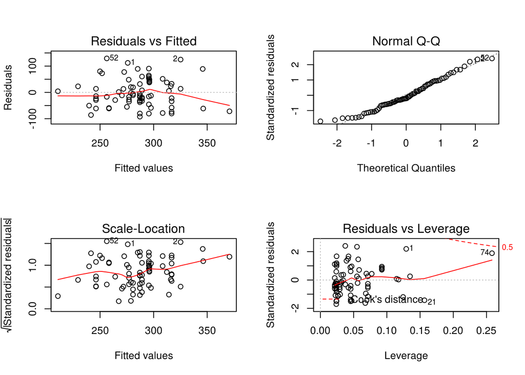

```r
par(mfrow = c(2,2))
plot(ModelonPrice)
```

- The residuals vs fitted f=plot shows a trend, and data is not scattered about evenly
- The Q-Q Plot does not follow the line exactly
- The scale-location plot also has a curve
- The residuals vs leverage shows a few points with high leverage

## 4) Model Modification

upon looking at the residuals vs fitted plot the data did not seem to be completely normal, so to try and fix this we took the natural log of the price.

```r
finalModelonLogPrice <-lm(logprice ~ bathcubed + lot + garagesize, data = housing)
summary(finalModelonLogPrice)
```

```
##
## Call:
## lm(formula = logprice ~ bathcubed + lot + garagesize, data = housing)
##
## Residuals:
##      Min       1Q   Median       3Q      Max
## -0.43148 -0.10259 -0.02308  0.13486  0.43122
##
## Coefficients:
##             Estimate Std. Error t value Pr(>|t|)
## (Intercept) 5.325127   0.075316  70.704  < 2e-16 ***
## bathcubed   0.005549   0.002485   2.233  0.02867 *
## lot         0.027401   0.014222   1.927  0.05797 .
## garagesize  0.081207   0.030342   2.676  0.00921 **
## ---
## Signif. codes:  0 '***' 0.001 '**' 0.01 '*' 0.05 '.' 0.1 ' ' 1
##
## Residual standard error: 0.1917 on 72 degrees of freedom
## Multiple R-squared:  0.2245, Adjusted R-squared:  0.1922
## F-statistic: 6.949 on 3 and 72 DF,  p-value: 0.0003583
```

- Compared to our last model, this model has a higher R-Squared value
- Bathcubed and Garagesize’s P-values became more significant, while Lot is just barely over the 0.05 threshold.

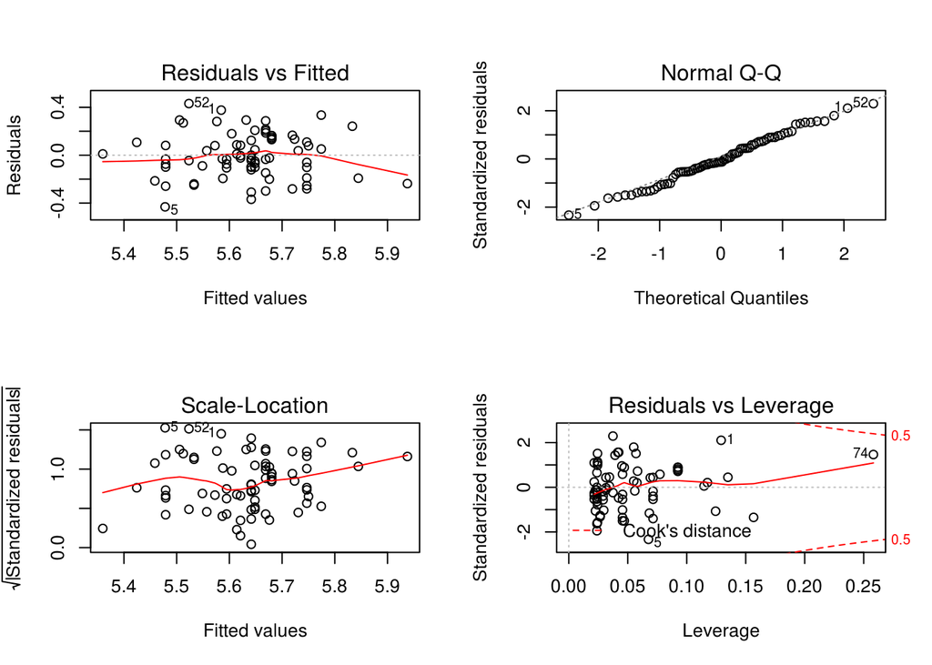

```r
par(mfrow = c(2,2))
plot(finalModelonLogPrice)
```

- Our residuals vs fitted plot looks a little better, but has a downward trend at the end
- The Normal Q-Q plot still doesnt look good, with points not following the line
- The Scale-Location has multiple curves to it, hinting at issues with orur model
- The residuals vs leverage has a lesser curve, and it appears that there are only 2 points with high leverage.

## 5.1) Confidence intervals for beta variables

- The confidence intervals for our $\beta$ variables are as follows:

```r
confint(finalModelonLogPrice)
```

```
##                     2.5 %     97.5 %
## (Intercept)  5.1749883159 5.47526584
## bathcubed    0.0005948302 0.01050337
## lot         -0.0009505588 0.05575192
## garagesize   0.0207225722 0.14169227
```

## 5.2) Confidence intervals for mean response

```r
newdata <- data.frame(bathcubed =  mean(housing$bath) ^ 3,
                       lot = mean(housing$lot),
                       garagesize = mean(housing$garagesize))
```

- Now that we have the mean responses for each predicter, we will feed it into the model and obtain a 95% CI

```r
predict(finalModelonLogPrice, newdata, interval="confidence")
```

```
##        fit      lwr      upr
## 1 5.621248 5.576147 5.666349
```

- For our prediction of our model using all mean variables
  - We are 95% confident that the true logprice value for the mean values of all beta variables lies between 5.5761 and 5.6663

## 5.3) Confidence interval for values of our choice

```r
sampledata <- data.frame(bathcubed =  2.5 ^ 3,
                       lot = 3,
                       garagesize = 1)
```

- We will test the CI for a house with 2.5 baths, a lot size of 3, and a garagesize of 1

```r
predict(finalModelonLogPrice, sampledata, interval="confidence")
```

```
##        fit      lwr      upr
## 1 5.575241 5.515661 5.634822
```

- For our prediction of our model using sample variables..
  - We are 95% confident that the true logprice value for the sample values lies between 5.515 and 5.635